# A2

Jenny Ly

16/03/2022

# Truck

#Oil | 1 2 3 4 5 # 1 | 0.500 0.634 0.487 0.329 0.512 # 2 | 0.535 0.675 0.520 0.435 0.540 # 3 | 0.513 0.595 0.488 0.400 0.510 #————————————————–

```r
#Question 1
#Analyze the data form this experiement (alpha=0.05)
y <- c(0.500,0.634,0.487,0.329,0.512,
       0.535,0.675,0.520,0.435,0.540,
       0.513,0.595,0.488,0.400,0.510)
oil.level <- rep(1:3,each=5)
truck.level <- rep(1:5,3)

oil <- factor(oil.level) #treatment = 3
truck <- factor(truck.level) #block = 5

fit <- aov(y~oil+truck,contrasts = list(oil=contr.sum, truck=contr.sum) )
anova(fit)
```

|  | Df | Sum Sq | Mean Sq | F value | Pr(>F) |
| --- | --- | --- | --- | --- | --- |
| oil | 2 | 0.006705733 | 0.0033528667 | 6.352733 | 2.228537e-02 |
| truck | 4 | 0.092099733 | 0.0230249333 | 43.625730 | 1.781342e-05 |
| Residuals | 8 | 0.004222267 | 0.0005277833 | NA | NA |

```r
#base on ANOVa table, at level 0.05, the treatment means different significantly

########################################################
#B-Use the Fisher LSD method
#to make comparisions among the three lubricaitng oils
#to determine specifically which oils differ in break-specific fuel consumption

library("agricolae")

test <- LSD.test(fit,trt = "oil", p.adj = "none", group = FALSE)
test
```

```
## $statistics
##        MSerror Df      Mean       CV  t.value        LSD
##   0.0005277833  8 0.5115333 4.491112 2.306004 0.03350564
##
## $parameters
##         test p.ajusted name.t ntr alpha
##   Fisher-LSD      none    oil   3  0.05
##
## $means
##        y        std r       LCL       UCL   Min   Max   Q25   Q50   Q75
## 1 0.4924 0.10865220 5 0.4687079 0.5160921 0.329 0.634 0.487 0.500 0.512
## 2 0.5410 0.08612491 5 0.5173079 0.5646921 0.435 0.675 0.520 0.535 0.540
## 3 0.5012 0.06969720 5 0.4775079 0.5248921 0.400 0.595 0.488 0.510 0.513
##
## $comparison
##       difference pvalue signif.         LCL         UCL
## 1 - 2    -0.0486 0.0102       * -0.08210564 -0.01509436
## 1 - 3    -0.0088 0.5615         -0.04230564  0.02470564
## 2 - 3     0.0398 0.0255       *  0.00629436  0.07330564
##
## $groups
## NULL
##
## attr(,"class")
## [1] "group"
```

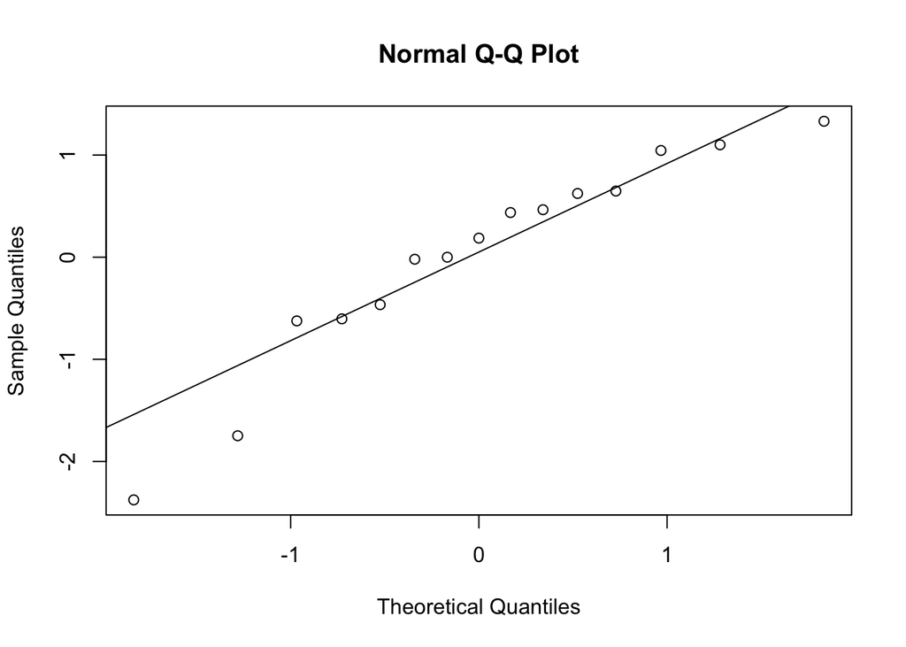

```r
#at level at 0.05, there's significant difference
#between oil 1&2, and oil number 2&3 in terms of break-specific fuel consumption

#C.Analyze the residuals from this experiment

# Standarized residuals and fitted values:
rcbd.r1<-rstandard(fit)
rcbd.fitted1<-fitted.values(fit)

# Normal Q-Q plot:
qqnorm(rcbd.r1,main="Normal Q-Q Plot")
qqline(rcbd.r1)
```

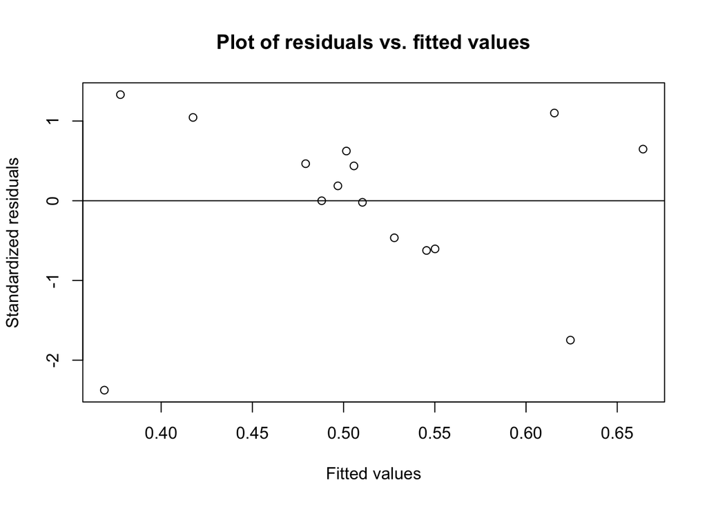

```r
#normal Q-Q plot indicates an approximate straight line relationship
#suggests that the error distribution is approximately normal

#Plot of residuals vs. fitted values:
plot(rcbd.fitted1,rcbd.r1,ylab="Standardized residuals",
  xlab="Fitted values",main="Plot of residuals vs. fitted values")
abline(h=0)
```

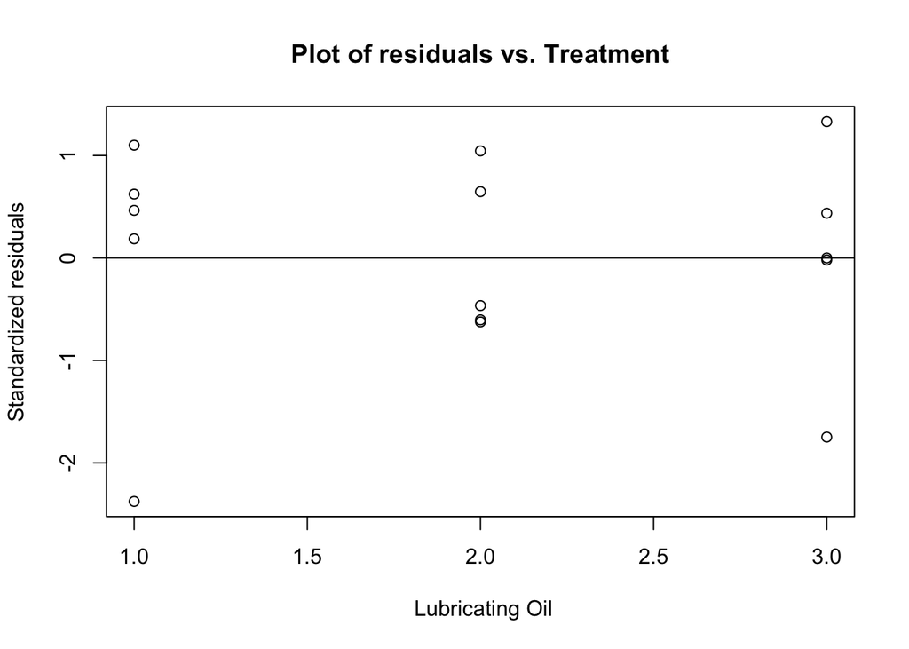

```r
#Comment: The plot of residuals vs fitted values verifies constant assumption

# Plot of residuals vs. treatment:
plot(oil.level,rcbd.r1,ylab="Standardized residuals",
  xlab=" Lubricating Oil",main="Plot of residuals vs. Treatment")
abline(h=0)
```

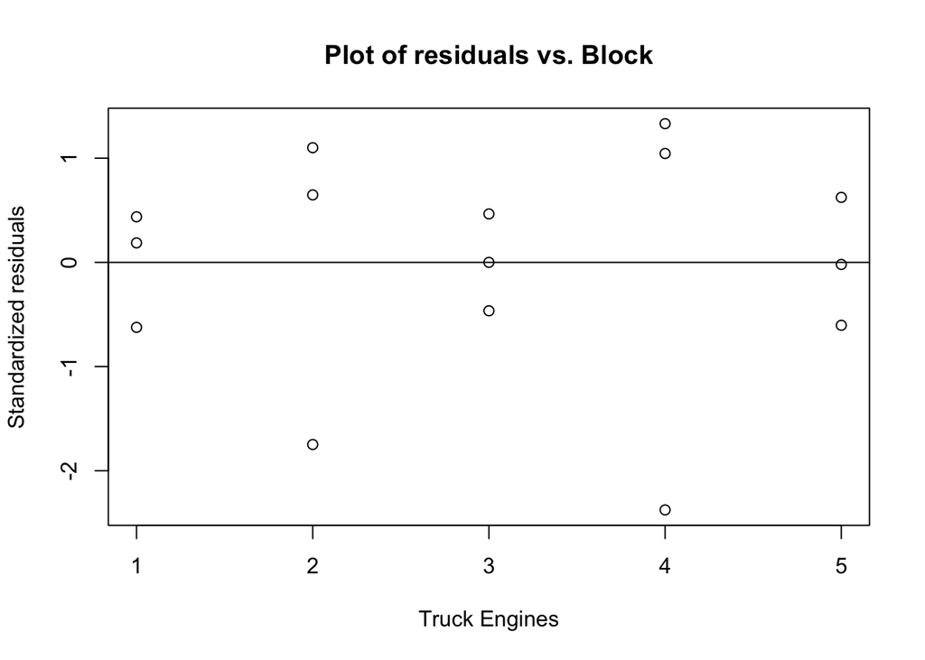

```r
#Comment: No indication of inequality of variance by treatment


# Plot of residuals vs. block:
plot(truck.level,rcbd.r1,ylab="Standardized residuals",
  xlab="Truck Engines",main="Plot of residuals vs. Block")
abline(h=0)
```

```r
#comment: Nothing unusual, all the blocks seem homogeneous
```

```r
#Question 2
#a/ Analyze the data from this experiment, alpha = 0.05
batchs <- factor(c(rep(1:5,5)))
day <- factor(c(rep(1:5, each=5)))
ingre <- factor(c("A","C","B","D","E",
           "B","E","A","C","D",
           "D","A","C","E","B",
           "C","D","E","B","A",
           "E","B","D","A","C"))
hour <- c(8,11,4,6,4,
          7,2,9,8,2,
          1,7,10,6,3,
          7,3,1,6,8,
          3,8,5,10,8)

myfit <- lm(hour~batchs+day+ingre)
anova(myfit)
```

|  | Df | Sum Sq | Mean Sq | F value | Pr(>F) |
| --- | --- | --- | --- | --- | --- |
| batchs | 4 | 15.44 | 3.860000 | 1.234542 | 0.3476182094 |
| day | 4 | 12.24 | 3.060000 | 0.978678 | 0.4550143404 |
| ingre | 4 | 141.44 | 35.360000 | 11.309168 | 0.0004876512 |
| Residuals | 12 | 37.52 | 3.126667 | NA | NA |

```r
#base on ANOVA table, at 95% CI treatment means differ significantly
#Differences between batches is not significant at level 0.05
#Also at level 0.05 no significant difference between days
```

#Suppose observation from batch 3 on day 4 is missing. Estimate missing value and perform analysis using this value

$p = 5$

$row.prime = 4+9+10+5 = 28$

$column.prime = 7+3+6+8=24$

$treament.prime = 4+2+6+3=15$

$grandtotal.prime=8+7+1+7+...+8 = 146$

$\hat{y}_{ijk}=\frac{5.(28+24+15)-2.146}{(5-2)(5-1)}=3.58=4$

```r
batch2 <- factor(c(rep(1:5,5)))
day2 <- factor(c(rep(1:5, each=5)))
ingre2 <- factor(c("A","C","B","D","E",
           "B","E","A","C","D",
           "D","A","C","E","B",
           "C","D","E","B","A",
           "E","B","D","A","C"))
hour2 <- c(8,11,4,6,4,
          7,2,9,8,2,
          1,7,10,6,3,
          7,3,4,6,8,
          3,8,5,10,8)

myfit2 <- lm(hour2~batch2+day2+ingre2)
anova(myfit2)
```

|  | Df | Sum Sq | Mean Sq | F value | Pr(>F) |
| --- | --- | --- | --- | --- | --- |
| batch2 | 4 | 16.4 | 4.100000 | 1.4302326 | 0.2831871173 |
| day2 | 4 | 8.4 | 2.100000 | 0.7325581 | 0.5870298491 |
| ingre2 | 4 | 126.8 | 31.700000 | 11.0581395 | 0.0005401648 |
| Residuals | 12 | 34.4 | 2.866667 | NA | NA |

```r
#at 0.05 level, there's still significant difference in treatment means
#batches and days effects are relatively small
```

```r
#Question 3
#Analyze the data from this experiment (alpha = 0.05)
trt <- c(2,4,6,8,10,12,14)
k <- 3
bib <- design.bib(trt,k,r=NULL)
```

```
##
## Parameters BIB
## ==============
## Lambda     : 1
## treatmeans : 7
## Block size : 3
## Blocks     : 7
## Replication: 3
##
## Efficiency factor 0.7777778
##
## <<< Book >>>
```

```r
bib
```

```
## $parameters
## $parameters$design
## [1] "bib"
##
## $parameters$trt
## [1]  2  4  6  8 10 12 14
##
## $parameters$k
## [1] 3
##
## $parameters$serie
## [1] 2
##
## $parameters$seed
## [1] -843132504
##
## $parameters$kinds
## [1] "Super-Duper"
##
##
## $statistics
##        lambda treatmeans blockSize blocks r Efficiency
## values      1          7         3      7 3  0.7777778
##
## $sketch
##      [,1] [,2] [,3]
## [1,] "14" "8"  "4"
## [2,] "10" "2"  "8"
## [3,] "10" "14" "6"
## [4,] "14" "2"  "12"
## [5,] "12" "6"  "8"
## [6,] "12" "4"  "10"
## [7,] "6"  "2"  "4"
##
## $book
##    plots block trt
## 1    101     1  14
## 2    102     1   8
## 3    103     1   4
## 4    201     2  10
## 5    202     2   2
## 6    203     2   8
## 7    301     3  10
## 8    302     3  14
## 9    303     3   6
## 10   401     4  14
## 11   402     4   2
## 12   403     4  12
## 13   501     5  12
## 14   502     5   6
## 15   503     5   8
## 16   601     6  12
## 17   602     6   4
## 18   603     6  10
## 19   701     7   6
## 20   702     7   2
## 21   703     7   4
```

$SS_T=(114)^2+(120)^2+....+(127)^2-\frac{2715}{21}=2600.29$

$SS_{Blocks}={\frac13}[(381)^2+....+(378)^2]-\frac{{(2715)}^2}{21}=1114.29$

$Q_1=351-\frac13[381+0+0+0+381+0+378]=-29$

$Q_2=365-\frac13[381+402+0+0+0+372+0]=-20$

$Q_3=388-\frac13[0+402+366+0+0+0+378]=6$

$Q_4=25$ $Q_5=32$ $Q_6=-12$ $Q_7=-2$

$SS_{treatment}=\frac{(-29)^2+(-20)^2+(6^2)+25^2+32^2+(-12^2+(-2^2))}{1.7}=1317.43$

$SS_E=2600.29-1114.29-1317.43=168.57$

$MS_E=\frac{168.57}{8}=21.07$

$MS_{treatment}=\frac{1317.43}{6}=219.57$

$MS_{blocks}=\frac{1114.29}{6}=185.72$

$F_o=\frac{219.57}{21.07}=10.42$

$F_{(6,8)}=2.66833$

$F_0>F_{(6,8)}$

#reject hypothesis.At level 0.05 there’s signifcant difference in treatments means